# Clustering — Café Arábica

K-means y Ward.D2 · Análisis en R

Juan Sebastián Guayazán · Esteban Valente · Diego Nocua

20 de noviembre de 2026

**En resumen.** Se agrupan los 1.070 lotes con K-means (k = 3, solución exploratoria) y Ward.D2 (muestra de 80 lotes). La separación es débil: la silueta de K-means es 0,116 y 104 lotes (9,7 %) tienen silueta negativa; la silueta promedio es incluso mayor con k = 2 (0,151) y el estadístico gap elige k = 1. El acuerdo entre K-means y Ward es moderado (ARI 0,471). Los grupos **no** son categorías comerciales (Specialty, Premium, Commodity).

# Qué responde este informe

**Pregunta:** ¿se pueden agrupar los lotes de café en grupos que tengan sentido, y qué tan confiables son esos grupos?

Cada sección sigue el mismo esquema: *qué se hace y por qué*, *el resultado* y *cómo se lee*.

| Sección | Qué se hace | Qué se concluye |
| --- | --- | --- |
| 1–3 | Preparar datos, PCA exploratorio y matriz X | Espacio de 4 scores PCA + indicadores categóricos |
| 4 | Elegir k con el codo | k = 3 es un candidato exploratorio, no un óptimo |
| 5 | K-means | Separación débil; grupos solapados; procedimiento estable |
| 6 | Ward.D2 | Árbol sobre una muestra de 80 lotes |
| 7 | Comparación | Acuerdo moderado; no prueba grupos reales |
| Anexo | Robustez con y sin atípicos | La conclusión no cambia al quitar los atípicos |

# Propósito y alcance

Se aplican K-means y clustering jerárquico Ward.D2 en R a los 1.070 lotes que pasan el filtro de altitud. Se conserva el flujo de clase para K-means: estandarizar la matriz X, examinar WSS con factoextra, fijar k a partir del gráfico, ajustar con 25 inicializaciones y visualizar con fviz_cluster.

El espacio de clustering combina cuatro scores PCA con tres variables categóricas codificadas como indicadores. La matriz se pondera por bloques para que las 15 columnas dummy no dominen solo por ser más numerosas. No se quitan las filas que el informe PCA posterior marca como atípicas. Por eso este análisis usa el PCA exploratorio sobre los 1.070 lotes; sus componentes no son los del PCA final ajustado después de retirar atípicos.

La elección k = 3 se usa como solución exploratoria, elegida visualmente en la curva WSS. Silhouette se reporta como validación y muestra que la separación es débil. El número de grupos no se traduce automáticamente en categorías Specialty, Premium o Commodity.

# 1. Preparar datos y PCA exploratorio

```r
library(dplyr)
library(car)
library(factoextra)
library(fastDummies)
library(cluster)
library(ggplot2)

data_raw <- read.csv("../data/arabica_data_cleaned.csv")
data_raw$.id_fila <- seq_len(nrow(data_raw))

vars_numericas <- c(
  "Aroma", "Flavor", "Aftertaste", "Acidity", "Body", "Balance",
  "Uniformity", "Clean.Cup", "Sweetness", "Cupper.Points", "Moisture",
  "Category.One.Defects", "Category.Two.Defects", "altitude_mean_meters"
)

datos_filtrados <- data_raw %>%
  filter(!is.na(altitude_mean_meters),
         altitude_mean_meters > 0,
         altitude_mean_meters <= 3000)

# Se conserva la selección de 8 variables activas del PCA vigente.
vars_activas <- setdiff(
  vars_numericas,
  c("Category.One.Defects", "Category.Two.Defects", "Moisture",
    "Sweetness", "Uniformity", "Clean.Cup")
)
datos_originales <- datos_filtrados %>%
  select(.id_fila, all_of(vars_activas))

stopifnot(nrow(datos_originales) == 1070L)
stopifnot(!anyNA(datos_originales[, vars_activas]))

datos_modelo <- datos_originales[, vars_activas, drop = FALSE]

sesgo <- function(x) mean((x - mean(x))^3) / sd(x)^3
sesgo_inicial <- sapply(datos_modelo, sesgo)
vars_transformar <- names(sesgo_inicial[abs(sesgo_inicial) > 1])

cat("Lotes usados:", nrow(datos_modelo), "\n")
```

```
## Lotes usados: 1070
```

```r
cat("Variables PCA activas:", paste(vars_activas, collapse = ", "), "\n")
```

```
## Variables PCA activas: Aroma, Flavor, Aftertaste, Acidity, Body, Balance, Cupper.Points, altitude_mean_meters
```

```r
cat("Variables con |sesgo| > 1:", paste(vars_transformar, collapse = ", "), "\n")
```

```
## Variables con |sesgo| > 1: Aroma, Flavor, Aftertaste, Acidity, Body, Balance, Cupper.Points
```

**Cómo se lee.** Se trabaja con los 1.070 lotes del filtro de altitud (sin retirar atípicos) y 8 variables activas. 7 de ellas superan |sesgo| 1 y se transforman con Yeo-Johnson (en la base de 1.070 lotes, los siete atributos sensoriales).

Yeo-Johnson se aplica selectivamente siguiendo el criterio del informe PCA actual (|sesgo| > 1). Se conserva la estimación de máxima verosimilitud de car; no se fuerzan lambdas a un rango arbitrario.

```r
if (length(vars_transformar) > 0) {
  ajuste_yj <- powerTransform(
    datos_modelo[, vars_transformar, drop = FALSE],
    family = "yjPower"
  )
  lambdas_yj <- coef(ajuste_yj, round = FALSE)
  print(round(lambdas_yj, 3))

  for (v in vars_transformar) {
    datos_modelo[[v]] <- yjPower(datos_modelo[[v]], lambdas_yj[v])
  }
}
```

```
##         Aroma        Flavor    Aftertaste       Acidity          Body
##         3.590         2.739         2.619         3.291         3.079
##       Balance Cupper.Points
##         2.295         2.177
```

```r
pca_exploratorio <- prcomp(datos_modelo, center = TRUE, scale. = TRUE)
varianza_acumulada_4pc <-
  sum(pca_exploratorio$sdev[1:4]^2) / sum(pca_exploratorio$sdev^2)

cat("Varianza acumulada por las primeras 4 CP:",
    round(varianza_acumulada_4pc * 100, 1), "%\n")
```

```
## Varianza acumulada por las primeras 4 CP: 88.6 %
```

**Cómo se lee.** Las primeras 4 componentes del PCA exploratorio conservan el 88,6 % de la varianza; son las que alimentan el clustering. Son componentes de los 1.070 lotes, no las del PCA final de 970.

# 2. Variables categóricas y alineación de filas

Se usan método de procesamiento, color y país de origen. País se resume en los cinco orígenes con más lotes y una categoría Otro. Se conserva una columna de identificador para verificar que cada fila dummy corresponde al mismo lote que sus scores PCA.

```r
categoricas <- datos_filtrados %>%
  select(.id_fila, Processing.Method, Color, Country.of.Origin) %>%
  mutate(across(
    c(Processing.Method, Color, Country.of.Origin),
    ~ ifelse(is.na(.) | trimws(as.character(.)) == "",
             "Desconocido", as.character(.))
  ))

top5_paises <- names(
  sort(table(categoricas$Country.of.Origin), decreasing = TRUE)[1:5]
)
categoricas$Country.of.Origin <- ifelse(
  categoricas$Country.of.Origin %in% top5_paises,
  categoricas$Country.of.Origin,
  "Otro"
)

stopifnot(identical(datos_originales$.id_fila, categoricas$.id_fila))
```

Se mantienen todos los indicadores de cada factor. Quitar una categoría de referencia evita colinealidad en ciertos modelos lineales, pero aquí cambiaría las distancias usadas por K-means y Ward.

```r
datos_categoricos <- categoricas %>%
  select(-.id_fila) %>%
  mutate(across(everything(), factor))

dummies <- model.matrix(
  ~ Processing.Method + Color + Country.of.Origin - 1,
  data = datos_categoricos
)

cat("Filas categóricas:", nrow(dummies), "\n")
```

```
## Filas categóricas: 1070
```

```r
cat("Columnas dummy:", ncol(dummies), "\n")
```

```
## Columnas dummy: 15
```

```r
cat("Filas PCA:", nrow(pca_exploratorio$x), "\n")
```

```
## Filas PCA: 1070
```

```r
stopifnot(nrow(dummies) == nrow(pca_exploratorio$x))
```

**Cómo se lee.** Hay 15 columnas indicadoras (una por categoría de proceso, color y país) para los mismos 1.070 lotes de los scores: la comprobación de alineación pasó.

# 3. Construir y escalar X

El código de clase estandariza X antes de ejecutar los algoritmos. Aquí se estandariza cada una de las cuatro CP y se divide el bloque numérico por la raíz de 4. El bloque dummy completo se divide por la raíz de 3 variables categóricas. Así, ambos bloques aportan aproximadamente la misma suma de cuadrados total; además, los indicadores no se estandarizan individualmente, lo que daría pesos muy grandes a categorías raras.

Esta ponderación es una decisión de distancia que debe quedar documentada. Más adelante se puede presentar el análisis de sensibilidad con otros pesos.

```r
X_num <- scale(pca_exploratorio$x[, 1:4, drop = FALSE]) / sqrt(4)
X_dum <- dummies / sqrt(3)
X_stand <- cbind(X_num, X_dum)

cat("Dimensiones de X:", nrow(X_stand), "×", ncol(X_stand), "\n")
```

```
## Dimensiones de X: 1070 × 19
```

```r
cat("Proporción de suma de cuadrados, bloque numérico:",
    round(sum(X_num^2) / sum(X_stand^2) * 100, 1), "%\n")
```

```
## Proporción de suma de cuadrados, bloque numérico: 51.4 %
```

```r
cat("Proporción de suma de cuadrados, bloque categórico:",
    round(sum(X_dum^2) / sum(X_stand^2) * 100, 1), "%\n")
```

```
## Proporción de suma de cuadrados, bloque categórico: 48.6 %
```

**Cómo se lee.** La matriz X tiene 19 columnas. Gracias a la ponderación, el bloque numérico aporta el 51,4 % de la suma de cuadrados y el categórico el 48,6 %: ninguno domina solo por tener más columnas.

# 4. Elegir k con el método del codo

Se limita el gráfico a k = 1,…,5 como en el ejemplo de clase. WSS disminuye siempre al aumentar k; se inspecciona la curva buscando dónde la reducción empieza a aplanarse. La selección visual no se automatiza mediante una segunda diferencia arbitraria.

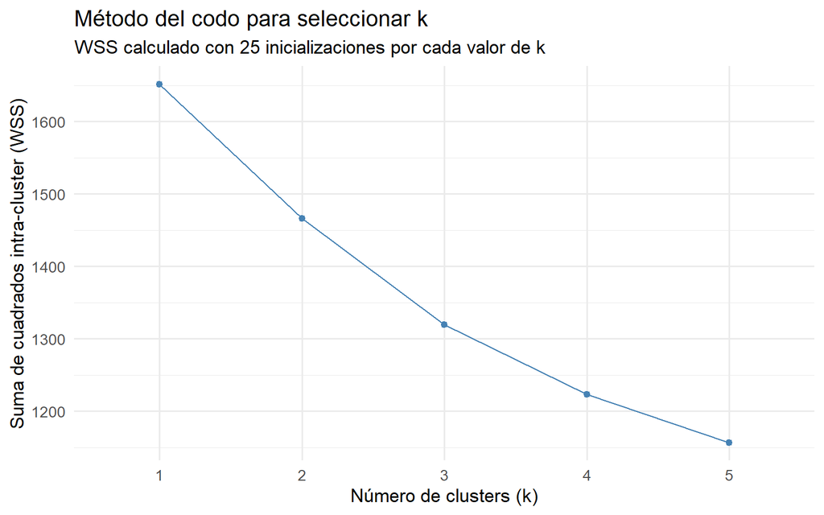

```r
set.seed(42)
grafico_wss <- fviz_nbclust(
  X_stand,
  kmeans,
  method = "wss",
  k.max = 5,
  nstart = 25
) +
  labs(
    title = "Método del codo para seleccionar k",
    subtitle = "WSS calculado con 25 inicializaciones por cada valor de k",
    x = "Número de clusters (k)",
    y = "Suma de cuadrados intra-cluster (WSS)"
  ) +
  theme_minimal(base_size = 13)

grafico_wss
```

**Cómo se lee.** La curva baja de forma gradual y no tiene un quiebre claro; se aplana poco a poco después de k = 3. Se fija k = 3 como candidato de trabajo para describir la solución y compararla con otros métodos; no se afirma que exista un óptimo estadístico único.

```r
k_optimo <- 3L
cat("k exploratorio seleccionado por inspección de WSS:", k_optimo, "\n")
```

```
## k exploratorio seleccionado por inspección de WSS: 3
```

# 5. K-means

## 5.1 Ajustar y visualizar

Se fija la semilla para que el informe sea reproducible y se usan 25 inicializaciones, como en el ejemplo de clase. La visualización reduce X a dos dimensiones para mostrar los grupos; las etiquetas se ajustaron en toda la matriz, no solo en ese plano.

```r
set.seed(42)
km <- kmeans(X_stand, centers = k_optimo, nstart = 25)

tabla_tamanos <- as.data.frame(table(cluster = km$cluster))
names(tabla_tamanos)[2] <- "lotes"
tabla_tamanos$porcentaje <- 100 * tabla_tamanos$lotes / nrow(X_stand)
tabla_tamanos
```

| cluster | lotes | porcentaje |
| --- | --- | --- |
| 1 | 247 | 23.08411 |
| 2 | 382 | 35.70093 |
| 3 | 441 | 41.21495 |

**Cómo se lee.** Los tres grupos tienen 247, 382, 441 lotes (23,1 %, 35,7 %, 41,2 %). No hay un grupo diminuto ni uno que domine.

Cada lote recibe una sola etiqueta de cluster en la matriz completa. El gráfico reduce esa matriz a dos dimensiones para poder verla; por eso, puntos de grupos distintos pueden quedar cerca o superpuestos en el plano. La proyección no cambia las asignaciones y las distancias entre puntos del dibujo no resumen todas las distancias que usó K-means.

```r
cat("BSS/TSS:",
    round(100 * km$betweenss / km$totss, 1), "%\n")
```

```
## BSS/TSS: 20.1 %
```

```r
sil_km <- silhouette(km$cluster, dist(X_stand))
cat("Silhouette promedio:",
    round(mean(sil_km[, 3]), 3), "\n")
```

```
## Silhouette promedio: 0.116
```

```r
cat("Observaciones con Silhouette negativa:",
    sum(sil_km[, 3] < 0), "de", nrow(X_stand),
    sprintf("(%.1f%%)\n", mean(sil_km[, 3] < 0) * 100))
```

```
## Observaciones con Silhouette negativa: 104 de 1070 (9.7%)
```

```r
sil_por_cluster <- aggregate(
  sil_km[, 3],
  by = list(cluster = sil_km[, 1]),
  FUN = mean
)
names(sil_por_cluster)[2] <- "silhouette_promedio"
sil_por_cluster
```

| cluster | silhouette_promedio |
| --- | --- |
| 1 | 0.08821055 |
| 2 | 0.16848473 |
| 3 | 0.08626911 |

**Cómo se lee.** BSS/TSS es el porcentaje de la variación total que queda **entre** grupos: 20,1 %; el resto es variación dentro de los grupos. La silueta promedio es 0,116 (va de −1 a 1; por debajo de 0,25 se considera que no hay estructura sustancial) y 104 lotes (9,7 %) tienen silueta negativa: quedan más cerca de otro grupo que del propio. Conclusión: **separación débil**.

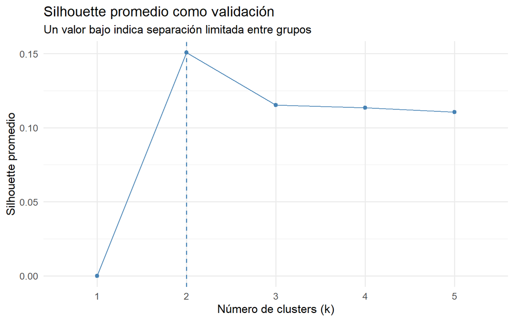

```r
set.seed(42)
fviz_nbclust(
  X_stand,
  kmeans,
  method = "silhouette",
  k.max = 5,
  nstart = 25
) +
  labs(
    title = "Silhouette promedio como validación",
    subtitle = "Un valor bajo indica separación limitada entre grupos",
    x = "Número de clusters (k)",
    y = "Silhouette promedio"
  ) +
  theme_minimal(base_size = 13)
```

**Cómo se lee.** La silueta promedio más alta se da con k = 2, no con k = 3. Esto confirma que k = 3 es una elección exploratoria para poder describir y comparar, no un óptimo.

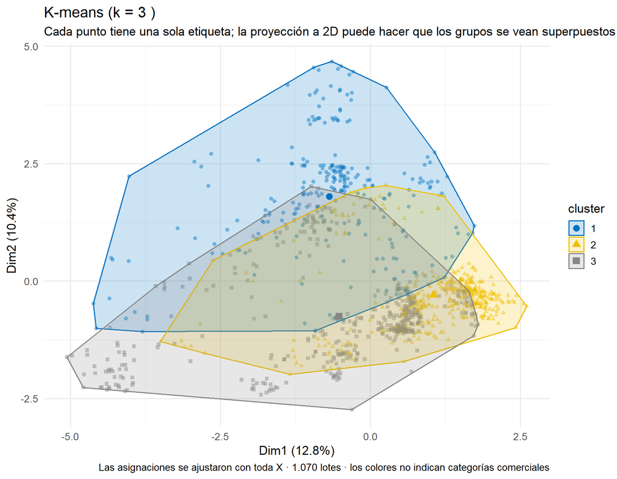

```r
grafico_kmeans <- fviz_cluster(
  km,
  data = X_stand,
  geom = "point",
  ellipse.type = "convex",
  palette = "jco",
  alpha = 0.45,
  ggtheme = theme_minimal()
) +
  labs(
    title = paste("K-means (k =", k_optimo, ")"),
    subtitle = "Cada punto tiene una sola etiqueta; la proyección a 2D puede hacer que los grupos se vean superpuestos",
    caption = "Las asignaciones se ajustaron con toda X · 1.070 lotes · los colores no indican categorías comerciales"
  ) +
  theme_minimal(base_size = 13) +
  theme(
    plot.background = element_rect(fill = "transparent", colour = NA),
    panel.background = element_rect(fill = "transparent", colour = NA),
    legend.background = element_rect(fill = "transparent", colour = NA),
    legend.key = element_rect(fill = "transparent", colour = NA)
  )

ggsave(
  "../imagenes_presentacion/kmeans_01_clusters.png",
  plot = grafico_kmeans,
  width = 12,
  height = 5.3,
  dpi = 180,
  bg = "transparent"
)

grafico_kmeans
```

**Cómo se lee.** Cada punto es un lote y cada color un grupo. Las envolventes son ayudas visuales, no fronteras reales. Los grupos se **traslapan** en el plano porque X tiene más dimensiones que las dos que se dibujan; cada lote tiene una sola etiqueta calculada en la matriz completa.

## 5.2 Sensibilidad a la inicialización

K-means puede llegar a soluciones distintas con distintos centros iniciales. Se compara la solución de referencia con 20 ejecuciones adicionales de 25 inicializaciones cada una, usando el índice Rand ajustado (ARI).

```r
ari <- function(a, b) {
  tab <- table(a, b)
  choose2 <- function(x) x * (x - 1) / 2
  n <- sum(tab)
  suma_celdas <- sum(choose2(tab))
  suma_filas <- sum(choose2(rowSums(tab)))
  suma_columnas <- sum(choose2(colSums(tab)))
  esperado <- suma_filas * suma_columnas / choose2(n)
  (suma_celdas - esperado) /
    (0.5 * (suma_filas + suma_columnas) - esperado)
}

ari_repeticiones <- numeric(20)
wss_repeticiones <- numeric(20)

for (i in seq_len(20)) {
  set.seed(1000 + i)
  km_i <- kmeans(X_stand, centers = k_optimo, nstart = 25)
  ari_repeticiones[i] <- ari(km$cluster, km_i$cluster)
  wss_repeticiones[i] <- km_i$tot.withinss
}

cat("ARI frente a la solución de referencia — rango:",
    paste(round(range(ari_repeticiones), 3), collapse = " a "), "\n")
```

```
## ARI frente a la solución de referencia — rango: 0.958 a 1
```

```r
cat("WSS entre las 20 repeticiones — rango:",
    paste(round(range(wss_repeticiones), 1), collapse = " a "), "\n")
```

```
## WSS entre las 20 repeticiones — rango: 1319.8 a 1319.8
```

```r
cat("Repeticiones idénticas a la referencia:",
    sum(ari_repeticiones == 1), "de 20\n")
```

```
## Repeticiones idénticas a la referencia: 16 de 20
```

**Cómo se lee.** El ARI mide qué tanto coinciden dos particiones (1 = idénticas). Con 20 semillas distintas el ARI frente a la solución de referencia va de 0,958 a 1,000, y 16 de 20 repeticiones son idénticas. Eso indica que el **procedimiento es estable**; no indica que los grupos sean naturales.

## 5.3 Perfil en las variables originales

Las etiquetas de K-means se unen a las variables originales usando el mismo orden de filas verificado antes. Los puntajes se reportan en su escala de origen para poder describir los grupos. Total.Cup.Points se usa solo para perfilar, no para ajustar el clustering.

```r
datos_perfil_km <- datos_filtrados %>%
  select(.id_fila, all_of(vars_numericas), Total.Cup.Points) %>%
  mutate(cluster = factor(km$cluster))

perfil_km <- datos_perfil_km %>%
  group_by(cluster) %>%
  summarise(
    lotes = n(),
    porcentaje = 100 * n() / nrow(datos_perfil_km),
    Aroma = mean(Aroma),
    Flavor = mean(Flavor),
    Aftertaste = mean(Aftertaste),
    Acidity = mean(Acidity),
    Body = mean(Body),
    Balance = mean(Balance),
    Cupper.Points = mean(Cupper.Points),
    Total.Cup.Points = mean(Total.Cup.Points),
    .groups = "drop"
  )

perfil_km
```

| cluster | lotes | porcentaje | Aroma | Flavor | Aftertaste | Acidity | Body | Balance | Cupper.Points | Total.Cup.Points |
| --- | --- | --- | --- | --- | --- | --- | --- | --- | --- | --- |
| 1 | 247 | 23.08411 | 7.608057 | 7.589595 | 7.463482 | 7.519757 | 7.559838 | 7.552713 | 7.566599 | 82.63449 |
| 2 | 382 | 35.70093 | 7.391597 | 7.280576 | 7.109058 | 7.369607 | 7.303953 | 7.228141 | 7.164607 | 80.11702 |
| 3 | 441 | 41.21495 | 7.702358 | 7.683832 | 7.595125 | 7.667098 | 7.647347 | 7.723651 | 7.716531 | 83.61270 |

**Cómo se lee.** El grupo con el mayor puntaje total promedio es el 3 (83,6 puntos) y el menor el 2 (80,1). Son **diferencias de promedio con distribuciones que se traslapan**, no categorías. `Total.Cup.Points` se usa solo para perfilar, no para ajustar.

No se asignan los nombres Specialty, Premium o Commodity desde el algoritmo. Para defender esas categorías se deben definir cortes externos de calidad y comprobar cómo se distribuyen los lotes de cada cluster respecto a ellos.

# 6. Clustering jerárquico Ward.D2

Se usa una muestra de 80 observaciones para que el dendrograma sea legible. El corte en k emplea el mismo candidato que K-means. La caja de rect.hclust marca el corte correcto; no se calcula una altura aproximada aparte.

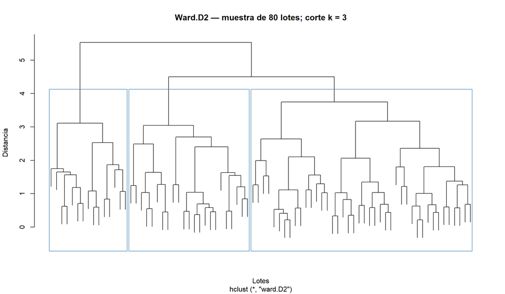

```r
set.seed(42)
idx_ward <- sample(seq_len(nrow(X_stand)), 80)
X_ward <- X_stand[idx_ward, , drop = FALSE]

hc_ward <- hclust(dist(X_ward), method = "ward.D2")
grupos_ward <- cutree(hc_ward, k = k_optimo)

plot(
  hc_ward,
  labels = FALSE,
  main = paste("Ward.D2 — muestra de 80 lotes; corte k =", k_optimo),
  xlab = "Lotes",
  ylab = "Distancia"
)
rect.hclust(hc_ward, k = k_optimo, border = "steelblue")
```

```r
cat("Tamaño de los grupos Ward en la muestra:\n")
```

```
## Tamaño de los grupos Ward en la muestra:
```

```r
print(table(grupos_ward))
```

```
## grupos_ward
##  1  2  3
## 15 42 23
```

**Cómo se lee.** El dendrograma une lotes parecidos de abajo hacia arriba; la altura de cada unión es la distancia a la que se fusionan. El corte en k = 3 da grupos de 15, 42, 23 lotes en la muestra. Las alturas de las últimas fusiones son graduales (5,53 · 4,50 · 3,75 · 3,17, según `revision_clustering_profesor.R`), así que el árbol también admitiría 4 grupos; se mantiene k = 3 como elección exploratoria.

Ward se ajustó sobre 80 lotes, mientras K-means usa los 1.070. Por tanto, el dendrograma ilustra el método y sus grupos no se comparan como si fueran etiquetas de toda la base.

## 6.1 Perfil de los grupos Ward en las variables originales

Promedios de los atributos sensoriales y del puntaje total para los 80 lotes de la muestra, en su escala original. Estas son las cifras que se citan en la presentación; describen solo la muestra y las distribuciones de los grupos se traslapan.

```r
perfil_ward <- datos_filtrados[idx_ward, ] %>%
  mutate(grupo_ward = factor(grupos_ward)) %>%
  group_by(grupo_ward) %>%
  summarise(
    lotes = n(),
    Aroma = mean(Aroma), Flavor = mean(Flavor), Aftertaste = mean(Aftertaste),
    Acidity = mean(Acidity), Body = mean(Body), Balance = mean(Balance),
    Cupper.Points = mean(Cupper.Points), Total.Cup.Points = mean(Total.Cup.Points),
    .groups = "drop"
  ) %>%
  mutate(across(where(is.numeric) & !lotes, ~ round(., 2)))
perfil_ward
```

| grupo_ward | lotes | Aroma | Flavor | Aftertaste | Acidity | Body | Balance | Cupper.Points | Total.Cup.Points |
| --- | --- | --- | --- | --- | --- | --- | --- | --- | --- |
| 1 | 15 | 7.71 | 7.58 | 7.47 | 7.51 | 7.59 | 7.52 | 7.53 | 82.86 |
| 2 | 42 | 7.58 | 7.57 | 7.46 | 7.58 | 7.59 | 7.63 | 7.60 | 82.72 |
| 3 | 23 | 7.38 | 7.27 | 7.05 | 7.36 | 7.27 | 7.20 | 7.21 | 79.90 |

**Cómo se lee.** En la muestra de 80 lotes, el grupo con más puntaje total es el 1 (82,86) y el menor el 3 (79,90). Dos grupos casi no se distinguen entre sí; el tercero es el más bajo en casi todos los atributos. Por eso no se nombran como categorías comerciales.

# 7. Comparación K-means y Ward.D2

Adjusted Rand Index compara las particiones de los mismos 80 lotes; no es una medida absoluta de calidad. Ward se muestra como método jerárquico ilustrativo en esa muestra, mientras K-means se ajusta a la base completa.

```r
ari_km_ward <- ari(km$cluster[idx_ward], grupos_ward)
sil_ward <- silhouette(grupos_ward, dist(X_ward))

resumen_metodos <- data.frame(
  Metodo = c("K-means", "Ward.D2"),
  Lotes_ajustados = c(nrow(X_stand), length(idx_ward)),
  Clusters = c(k_optimo, length(unique(grupos_ward))),
  Silhouette_promedio = c(
    mean(sil_km[, 3]),
    mean(sil_ward[, 3])
  ),
  Nota = c(
    "Todos los lotes; silhouette en X",
    "Muestra de 80; silhouette en la muestra"
  )
)

resumen_metodos
```

| Metodo | Lotes_ajustados | Clusters | Silhouette_promedio | Nota |
| --- | --- | --- | --- | --- |
| K-means | 1070 | 3 | 0.1160690 | Todos los lotes; silhouette en X |
| Ward.D2 | 80 | 3 | 0.1277064 | Muestra de 80; silhouette en la muestra |

```r
cat("ARI K-means / Ward.D2, muestra:", round(ari_km_ward, 3), "\n")
```

```
## ARI K-means / Ward.D2, muestra: 0.471
```

**Cómo se lee.** El ARI entre K-means y Ward en la misma muestra de 80 lotes es 0,471: coincidencia moderada, que no basta para afirmar que existan grupos reales. Las siluetas de la tabla no son comparables entre sí porque se calculan sobre conjuntos distintos (todos los lotes o una muestra de 80).

Las métricas de Ward se restringen a una muestra de 80 y no son directamente comparables con las de K-means sobre los 1.070 lotes. Ambos métodos usan distancia euclídea y buscan grupos compactos; sus resultados dependen de la representación y ponderación de las variables.

# Conclusiones

El flujo de código sigue el procedimiento visto en clase. La solución k = 3 es una elección visual exploratoria del codo, no una certificación de que existan tres segmentos naturales. De hecho, en `revision_clustering_profesor.R` la silueta promedio es máxima en k = 2 y el estadístico gap elige k = 1, es decir, no encuentra evidencia de que los datos estén más agrupados que una referencia sin estructura. Silhouette, tamaños, estabilidad y perfiles en variables originales deben leerse conjuntamente. Los nombres comerciales solo se justifican si criterios de calidad externos, definidos antes de ver los clusters, muestran una correspondencia clara.

# Anexo: robustez del agrupamiento (1.070 lotes vs. sin atípicos)

Compara K-means (k = 2 a 6), Ward.D2 y HDBSCAN (minPts = 15) sobre la base de 1.070 lotes y sobre la base de 970 lotes sin atípicos (`base_sin_atipicos.rds`). Sirve para ver si la estructura cambia al quitar los atípicos.

**Importante:** este anexo usa **otra matriz**: las 8 variables numéricas transformadas y estandarizadas, sin las variables categóricas ni la ponderación por bloques. Por eso sus siluetas (≈ 0,26) no son comparables con la del análisis principal (0,116), y aquí Ward se ajusta con todos los lotes, no con la muestra de 80. Con minPts = 15, HDBSCAN en R deja todos los lotes como ruido en esta matriz; los seis grupos que se presentan vienen del script de Python (`hdbscan_python.py`), que usa otra matriz (la del análisis principal) y tamaño mínimo de grupo 10.

```r
suppressMessages(library(cluster))
has_db <- requireNamespace("dbscan", quietly = TRUE)
res <- list()
for (base in c("../datos/base_1070.rds", "../datos/base_sin_atipicos.rds")) {
  tag <- if (base == "../datos/base_1070.rds") "1070" else "sin_atip"
  X <- as.matrix(readRDS(base)$Z); n <- nrow(X); D <- dist(X)
  cat("\n== base", tag, "n =", n, "\n")
  set.seed(2026)
  sil_k <- sapply(2:6, function(k) { km <- kmeans(X, k, nstart = 25); mean(silhouette(km$cluster, D)[, 3]) })
  cat("K-means silueta k=2..6:", round(sil_k, 3), "\n")
  km3 <- kmeans(X, 3, nstart = 25)
  cat("K-means k=3 silueta:", round(mean(silhouette(km3$cluster, D)[, 3]), 3), " negativas:", sum(silhouette(km3$cluster, D)[, 3] < 0), "(", round(mean(silhouette(km3$cluster, D)[, 3] < 0) * 100, 1), "%)\n")
  hc <- hclust(D, method = "ward.D2")
  cw <- cutree(hc, 3)
  cat("Ward.D2 k=3 silueta:", round(mean(silhouette(cw, D)[, 3]), 3), " tamaños:", table(cw), "\n")
  if (has_db) {
    hdb <- dbscan::hdbscan(X, minPts = 15)
    cat("HDBSCAN minPts=15: grupos =", length(unique(hdb$cluster[hdb$cluster > 0])), " ruido =", sum(hdb$cluster == 0), " (", round(mean(hdb$cluster == 0) * 100, 1), "%)\n")
  } else cat("HDBSCAN: paquete dbscan no instalado\n")
}
```

```
##
## == base 1070 n = 1070
## K-means silueta k=2..6: 0.303 0.259 0.213 0.213 0.214
## K-means k=3 silueta: 0.259  negativas: 20 ( 1.9 %)
## Ward.D2 k=3 silueta: 0.274  tamaños: 68 648 354
## HDBSCAN minPts=15: grupos = 0  ruido = 1070  ( 100 %)
##
## == base sin_atip n = 970
## K-means silueta k=2..6: 0.343 0.258 0.199 0.199 0.182
## K-means k=3 silueta: 0.258  negativas: 24 ( 2.5 %)
## Ward.D2 k=3 silueta: 0.227  tamaños: 254 544 172
## HDBSCAN minPts=15: grupos = 0  ruido = 970  ( 100 %)
```

**Cómo se lee.** Para cada base se muestran las siluetas de K-means con k de 2 a 6, la de k = 3, la de Ward y el resultado de HDBSCAN. Si las siluetas se mantienen bajas y parecidas con y sin los 100 atípicos, la conclusión de **separación débil no depende de haberlos retirado**. Esta matriz es otra (solo las 8 variables numéricas), por eso sus siluetas no se comparan con las del análisis principal.